# TP RECONSTRUCTION DES GRAPHES

1. Install and load the following R packages: bnlearn, igraph, pcalg and miic

```r
if (!require("BiocManager", quietly = TRUE))
  install.packages("BiocManager")
BiocManager::install("graph")
n

if (!require("Bioconductor", quietly = TRUE))
  install.packages("Bioconductor")
BiocManager::install("RBGL")
n
BiocManager::install("Rgraphviz")
n
```

```r
library(tidyverse)
library(corrr)
library(igraph)
library(ggraph)
library(bnlearn)
library(pcalg)
library(miic)
library(Rgraphviz)
```

2. Create the insurance ground truth model from the model string (see insurance help). (0.5 points)

```r
data("insurance")
help("insurance")

modelstring = paste0("[Age][Mileage][SocioEcon|Age][GoodStudent|Age:SocioEcon]",
                     "[RiskAversion|Age:SocioEcon][OtherCar|SocioEcon][VehicleYear|SocioEcon:RiskAversion]",
                     "[MakeModel|SocioEcon:RiskAversion][SeniorTrain|Age:RiskAversion]",
                     "[HomeBase|SocioEcon:RiskAversion][AntiTheft|SocioEcon:RiskAversion]",
                     "[RuggedAuto|VehicleYear:MakeModel][Antilock|VehicleYear:MakeModel]",
                     "[DrivingSkill|Age:SeniorTrain][CarValue|VehicleYear:MakeModel:Mileage]",
                     "[Airbag|VehicleYear:MakeModel][DrivQuality|RiskAversion:DrivingSkill]",
                     "[Theft|CarValue:HomeBase:AntiTheft][Cushioning|RuggedAuto:Airbag]",
                     "[DrivHist|RiskAversion:DrivingSkill][Accident|DrivQuality:Mileage:Antilock]",
                     "[ThisCarDam|RuggedAuto:Accident][OtherCarCost|RuggedAuto:Accident]",
                     "[MedCost|Age:Accident:Cushioning][ILiCost|Accident]",
                     "[ThisCarCost|ThisCarDam:Theft:CarValue][PropCost|ThisCarCost:OtherCarCost]")

data = model2network(modelstring)
```

3. Check the class of the returned object and see the content. (0.5 points)

```r
data
```

```
  Random/Generated Bayesian network

  model:
   [Age][Mileage][SocioEcon|Age][GoodStudent|Age:SocioEcon][OtherCar|SocioEcon]
   [RiskAversion|Age:SocioEcon][AntiTheft|RiskAversion:SocioEcon]
   [HomeBase|RiskAversion:SocioEcon][MakeModel|RiskAversion:SocioEcon]
   [SeniorTrain|Age:RiskAversion][VehicleYear|RiskAversion:SocioEcon]
   [Airbag|MakeModel:VehicleYear][Antilock|MakeModel:VehicleYear]
   [CarValue|MakeModel:Mileage:VehicleYear][DrivingSkill|Age:SeniorTrain]
   [RuggedAuto|MakeModel:VehicleYear][Cushioning|Airbag:RuggedAuto]
   [DrivHist|DrivingSkill:RiskAversion][DrivQuality|DrivingSkill:RiskAversion]
   [Theft|AntiTheft:CarValue:HomeBase][Accident|Antilock:DrivQuality:Mileage]
   [ILiCost|Accident][MedCost|Accident:Age:Cushioning][OtherCarCost|Accident:RuggedAuto]
   [ThisCarDam|Accident:RuggedAuto][ThisCarCost|CarValue:Theft:ThisCarDam]
   [PropCost|OtherCarCost:ThisCarCost]
  nodes:                                 27
  arcs:                                  52
    undirected arcs:                     0
    directed arcs:                       52
  average markov blanket size:           5.19
  average neighbourhood size:            3.85
  average branching factor:              1.93

  generation algorithm:                  Empty
```

```r
class(data)
```

```
[1] "bn"
```

La fonction class() nous donne le type d’un objet passé en paramètre. le type de l’objet data est “bn” qui est un modèle probabiliste qui permet de représenter les relations causales entre différentes variables aléatoires.

4. Get the adjacency matrix (bnlearn::amat). (0.5 points)

```r
mat <- amat(data) #matrice d'adjacence
mat
```

```
             Accident Age Airbag Antilock AntiTheft CarValue Cushioning DrivHist
Accident            0   0      0        0         0        0          0        0
Age                 0   0      0        0         0        0          0        0
Airbag              0   0      0        0         0        0          1        0
Antilock            1   0      0        0         0        0          0        0
AntiTheft           0   0      0        0         0        0          0        0
CarValue            0   0      0        0         0        0          0        0
Cushioning          0   0      0        0         0        0          0        0
DrivHist            0   0      0        0         0        0          0        0
DrivingSkill        0   0      0        0         0        0          0        1
DrivQuality         1   0      0        0         0        0          0        0
GoodStudent         0   0      0        0         0        0          0        0
HomeBase            0   0      0        0         0        0          0        0
ILiCost             0   0      0        0         0        0          0        0
MakeModel           0   0      1        1         0        1          0        0
MedCost             0   0      0        0         0        0          0        0
Mileage             1   0      0        0         0        1          0        0
OtherCar            0   0      0        0         0        0          0        0
OtherCarCost        0   0      0        0         0        0          0        0
PropCost            0   0      0        0         0        0          0        0
RiskAversion        0   0      0        0         1        0          0        1
RuggedAuto          0   0      0        0         0        0          1        0
SeniorTrain         0   0      0        0         0        0          0        0
SocioEcon           0   0      0        0         1        0          0        0
Theft               0   0      0        0         0        0          0        0
ThisCarCost         0   0      0        0         0        0          0        0
ThisCarDam          0   0      0        0         0        0          0        0
VehicleYear         0   0      1        1         0        1          0        0
             DrivingSkill DrivQuality GoodStudent HomeBase ILiCost MakeModel MedCost
Accident                0           0           0        0       1         0       1
Age                     1           0           1        0       0         0       1
Airbag                  0           0           0        0       0         0       0
Antilock                0           0           0        0       0         0       0
AntiTheft               0           0           0        0       0         0       0
CarValue                0           0           0        0       0         0       0
Cushioning              0           0           0        0       0         0       1
DrivHist                0           0           0        0       0         0       0
DrivingSkill            0           1           0        0       0         0       0
DrivQuality             0           0           0        0       0         0       0
GoodStudent             0           0           0        0       0         0       0
```

[output cut: 57 more lines]

```
ILiCost              0     0           0          0           0
MakeModel            0     0           0          0           0
MedCost              0     0           0          0           0
Mileage              0     0           0          0           0
OtherCar             0     0           0          0           0
OtherCarCost         0     0           0          0           0
PropCost             0     0           0          0           0
RiskAversion         0     0           0          0           1
RuggedAuto           0     0           0          1           0
SeniorTrain          0     0           0          0           0
SocioEcon            0     0           0          0           1
Theft                0     0           1          0           0
ThisCarCost          0     0           0          0           0
ThisCarDam           0     0           1          0           0
VehicleYear          0     0           0          0           0
```

La matrice d’adjacence permet représenter sous forme matricielle la relation entre les differents noeuds du graphe.Lorsqu’on a 1, cela signifie qu’il y a un lien entre les deux variables et 0 sinon!

5. Build a directed igraph network from the adjacency matrix and propose a (nice! eg., color the edge, the vertices etc…) plot. (0.5 points)

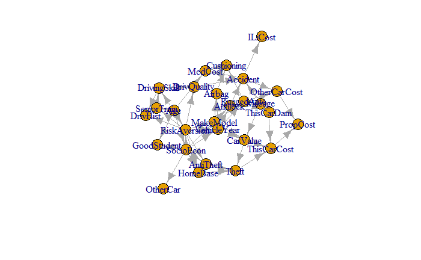

```r
#Create igraph from graph
myIgraph <- igraph::graph_from_adjacency_matrix(mat, mode="directed")
plot(myIgraph)
```

```
Using "stress" as default layout
```

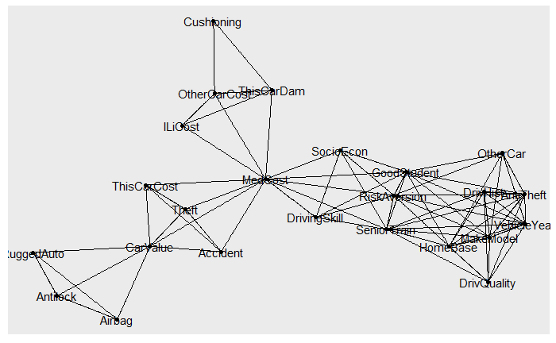

```r
tidy_cors <- mat %>%
 correlate() %>%
 stretch()
graph_cors <- tidy_cors %>%
  filter(abs(r) > .1) %>%
  graph_from_data_frame(directed = FALSE)


# Plot with ggraph
ggraph(graph_cors) +
  geom_edge_link() +
  geom_node_point() +
  geom_node_text(aes(label = name))
```

```
Using "stress" as default layout
```

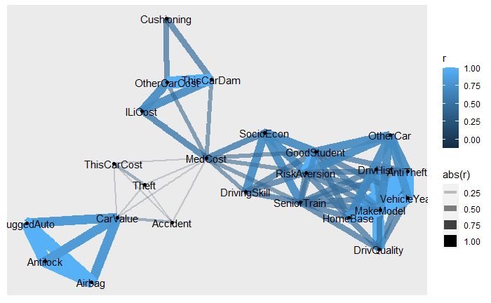

```r
# Make a fancy plot
# 1 --> improve edges display
ggraph(graph_cors) +
  geom_edge_link(aes(edge_alpha = abs(r), edge_width = abs(r), color = r)) +
  geom_node_point() +
  geom_node_text(aes(label = name))
```

```
Using "stress" as default layout
```

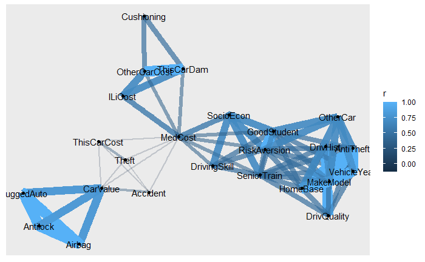

```r
# 2 --> reduce side legend
ggraph(graph_cors) +
  geom_edge_link(aes(edge_alpha = abs(r), edge_width = abs(r), color = r)) +
  guides(edge_alpha = "none", edge_width = "none") +
  geom_node_point() +
  geom_node_text(aes(label = name))
```

```
Using "stress" as default layout
```

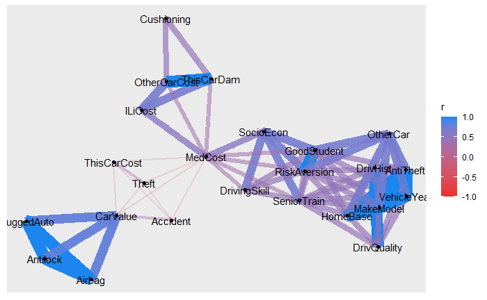

```r
# 3 --> Improve the color gradient
ggraph(graph_cors) +
  geom_edge_link(aes(edge_alpha = abs(r), edge_width = abs(r), color = r)) +
  guides(edge_alpha = "none", edge_width = "none") +
  scale_edge_colour_gradientn(limits = c(-1, 1), colors = c("firebrick2", "dodgerblue2"))+
  geom_node_point() +
  geom_node_text(aes(label = name))
```

```
Using "stress" as default layout
```

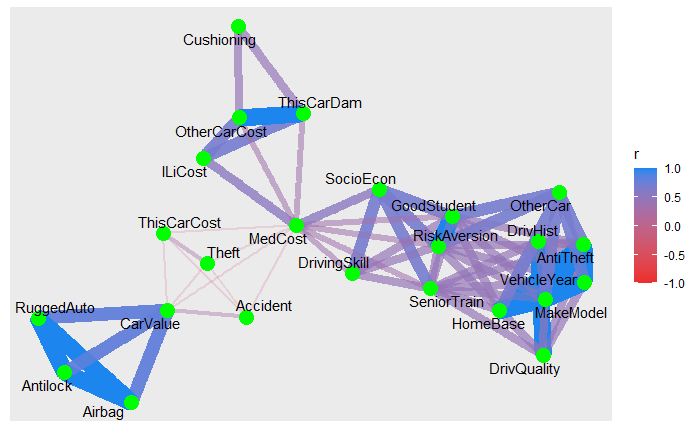

```r
# 4 --> Improve node display and associated text
ggraph(graph_cors) +
  geom_edge_link(aes(edge_alpha = abs(r), edge_width = abs(r), color = r)) +
  guides(edge_alpha = "none", edge_width = "none") +
  scale_edge_colour_gradientn(limits = c(-1, 1), colors = c("firebrick2", "dodgerblue2"))+
  geom_node_point(color = "green", size = 5) +
  geom_node_text(aes(label = name), repel = TRUE)
```

```
Using "stress" as default layout
```

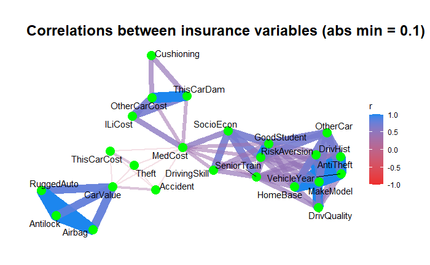

```r
#5 --> Remove background grid and set title
ggraph(graph_cors) +
  geom_edge_link(aes(edge_alpha = abs(r), edge_width = abs(r), color = r)) +
  guides(edge_alpha = "none", edge_width = "none") +
  scale_edge_colour_gradientn(limits = c(-1, 1), colors = c("firebrick2", "dodgerblue2"))+
  geom_node_point(color = "green", size = 5) +
  geom_node_text(aes(label = name), repel = TRUE) +
  theme_graph() +
 labs(title = "Correlations between insurance variables (abs min = 0.1)")
```

Sur ce graphe, on remarqu’il y a des variables qui apportent la même informations (celles qui sont fortement correlées) deplus, le graphe est divisé en deux c’est à dire qu’il y a globalement deux familles de vatiables.

1. Load the insurance data from the bnlearn package.

```r
data("insurance")
```

2. Reconstruct the insurance network using the hill-climbing approach (bnlearn::hc). Check the class of the returned object and see the content. (0.5 points)

```r
#Call to hill climbing
myHc <- bnlearn::hc(insurance)
class(myHc)
```

```
[1] "bn"
```

```r
myHc
```

```
  Bayesian network learned via Score-based methods

  model:
   [RuggedAuto][MakeModel|RuggedAuto][CarValue|RuggedAuto:MakeModel][Mileage|CarValue]
   [VehicleYear|MakeModel:Mileage:CarValue][SocioEcon|VehicleYear:MakeModel]
   [Antilock|VehicleYear:MakeModel][Airbag|VehicleYear:MakeModel]
   [ThisCarDam|Mileage:Antilock][OtherCar|SocioEcon][Cushioning|RuggedAuto:Airbag]
   [Accident|ThisCarDam:RuggedAuto][ThisCarCost|ThisCarDam:CarValue]
   [MedCost|ThisCarDam:Cushioning][DrivQuality|Accident:Mileage]
   [Theft|ThisCarDam:ThisCarCost][OtherCarCost|RuggedAuto:Accident][ILiCost|Accident]
   [Age|SocioEcon:DrivQuality][PropCost|ThisCarCost:OtherCarCost]
   [GoodStudent|Age:SocioEcon][SeniorTrain|Age:DrivQuality]
   [RiskAversion|Age:DrivQuality:SeniorTrain][DrivingSkill|RiskAversion:DrivQuality]
   [HomeBase|SocioEcon:RiskAversion][AntiTheft|SocioEcon:RiskAversion]
   [DrivHist|RiskAversion:DrivingSkill]
  nodes:                                 27
  arcs:                                  50
    undirected arcs:                     0
    directed arcs:                       50
  average markov blanket size:           4.44
  average neighbourhood size:            3.70
  average branching factor:              1.85

  learning algorithm:                    Hill-Climbing
  score:                                 BIC (disc.)
  penalization coefficient:              4.951744
  tests used in the learning procedure:  1755
  optimized:                             TRUE
```

3. Get the adjacency matrix (bnlearn::amat). (0.5 points)

```r
#get adj mat from HC graph
myHcAdj <- amat(myHc)
```

4. Build a directed igraph network from the adjacency matrix

```r
#Create igraph from graph
myIgraph <- igraph::graph_from_adjacency_matrix(myHcAdj, mode="directed")
#plot(myIgraph)
```

and propose a (nice!) plot. (1 point)

```
Using "stress" as default layout
```

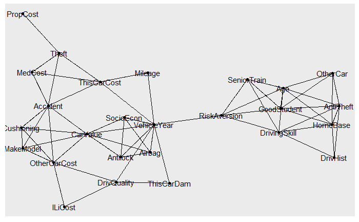

```r
tidy_cors <- myHcAdj %>%
 correlate() %>%
 stretch()
graph_cors <- tidy_cors %>%
  filter(abs(r) > .1) %>%
  graph_from_data_frame(directed = FALSE)


# Plot with ggraph
ggraph(graph_cors) +
  geom_edge_link() +
  geom_node_point() +
  geom_node_text(aes(label = name))
```

```
Using "stress" as default layout
```

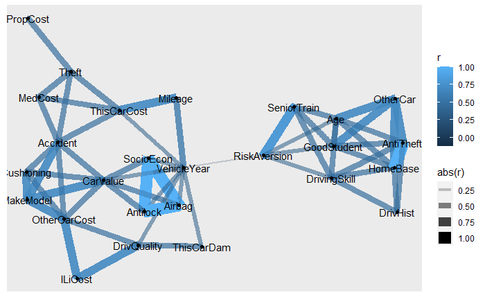

```r
# Make a fancy plot
# 1 --> improve edges display
ggraph(graph_cors) +
  geom_edge_link(aes(edge_alpha = abs(r), edge_width = abs(r), color = r)) +
  geom_node_point() +
  geom_node_text(aes(label = name))
```

```
Using "stress" as default layout
```

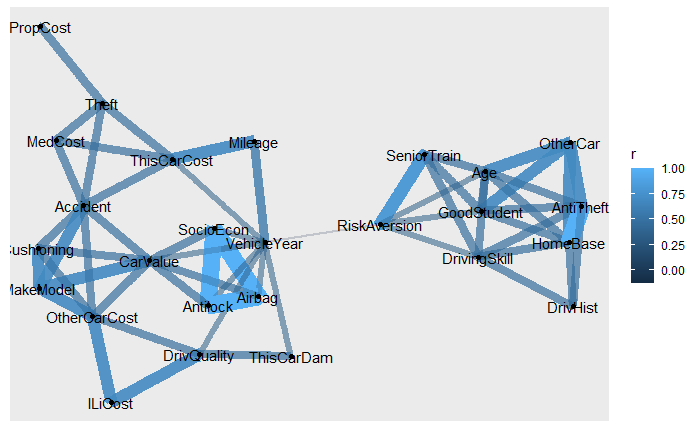

```r
# 2 --> reduce side legend
ggraph(graph_cors) +
  geom_edge_link(aes(edge_alpha = abs(r), edge_width = abs(r), color = r)) +
  guides(edge_alpha = "none", edge_width = "none") +
  geom_node_point() +
  geom_node_text(aes(label = name))
```

```
Using "stress" as default layout
```

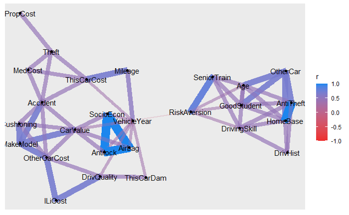

```r
# 3 --> Improve the color gradient
ggraph(graph_cors) +
  geom_edge_link(aes(edge_alpha = abs(r), edge_width = abs(r), color = r)) +
  guides(edge_alpha = "none", edge_width = "none") +
  scale_edge_colour_gradientn(limits = c(-1, 1), colors = c("firebrick2", "dodgerblue2"))+
  geom_node_point() +
  geom_node_text(aes(label = name))
```

```
Using "stress" as default layout
```

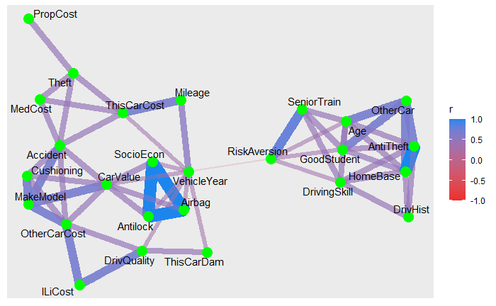

```r
# 4 --> Improve node display and associated text
ggraph(graph_cors) +
  geom_edge_link(aes(edge_alpha = abs(r), edge_width = abs(r), color = r)) +
  guides(edge_alpha = "none", edge_width = "none") +
  scale_edge_colour_gradientn(limits = c(-1, 1), colors = c("firebrick2", "dodgerblue2"))+
  geom_node_point(color = "green", size = 5) +
  geom_node_text(aes(label = name), repel = TRUE)
```

```
Using "stress" as default layout
```

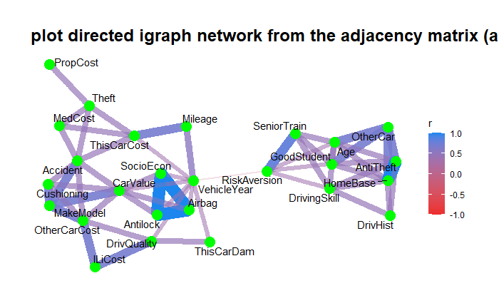

```r
#5 --> Remove background grid and set title
ggraph(graph_cors) +
  geom_edge_link(aes(edge_alpha = abs(r), edge_width = abs(r), color = r)) +
  guides(edge_alpha = "none", edge_width = "none") +
  scale_edge_colour_gradientn(limits = c(-1, 1), colors = c("firebrick2", "dodgerblue2"))+
  geom_node_point(color = "green", size = 5) +
  geom_node_text(aes(label = name), repel = TRUE) +
  theme_graph() +
 labs(title = "plot directed igraph network from the adjacency matrix (abs min = 0.1)")
```

5. Get the number of true positive (TP), false positive (FP) and false negative (FN) using the bnlearn::compare function. Compute Precision, Recall and Fscore. (1 point)

```r
true_model <- data

# Learn the structure of the estimated network from the data
estimated_model <- myHc

# Compare the true and estimated networks
comparison <- compare(true_model, estimated_model)
```

```r
# Extract the number of true positives (TP)
tp <- comparison$tp

# Extract the number of false positives (FP)
fp <- comparison$fp

# Extract the number of false negatives (FN)
fn <- comparison$fn

# Compute precision
precision <- tp / (tp + fp)

# Compute recall
recall <- tp / (tp + fn)

# Compute F-score
fscore <- 2 * (precision * recall) / (precision + recall)

print(precision)
```

```
[1] 0.52
```

```r
print(recall)
```

```
[1] 0.5
```

```r
print(fscore)
```

```
[1] 0.5098039
```

Lorsque nous prenons en compte l’orientation, notre modèle a une précision de 0.52 en d’autres termes, lorsqu’il prédit la relation entre deux noeuds elle est correcte dans 52% des cas.

Essayons de faire une comparaison sans tenir compte de la direction (on s’interesse uniquement aux squelettes).

```r
# Compare the true and estimated networks
comparison <- compare(bnlearn::skeleton(true_model), bnlearn::skeleton(estimated_model))
```

```r
# Extract the number of true positives (TP)
tp <- comparison$tp

# Extract the number of false positives (FP)
fp <- comparison$fp

# Extract the number of false negatives (FN)
fn <- comparison$fn

# Compute precision
precision <- tp / (tp + fp)

# Compute recall
recall <- tp / (tp + fn)

# Compute F-score
fscore <- 2 * (precision * recall) / (precision + recall)

print(precision)
```

```
[1] 0.76
```

```r
print(recall)
```

```
[1] 0.7307692
```

```r
print(fscore)
```

```
[1] 0.745098
```

Lorsqu’on s’interesse uniquement aux squelettes, les résultats sont meilleurs: on peut dire que l’orientation influence la prédiction.

6. Highlight the FP edges in your reconstructed network with a particular color. (1 point)

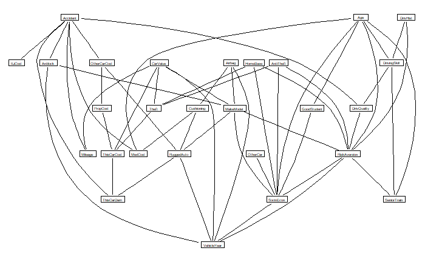

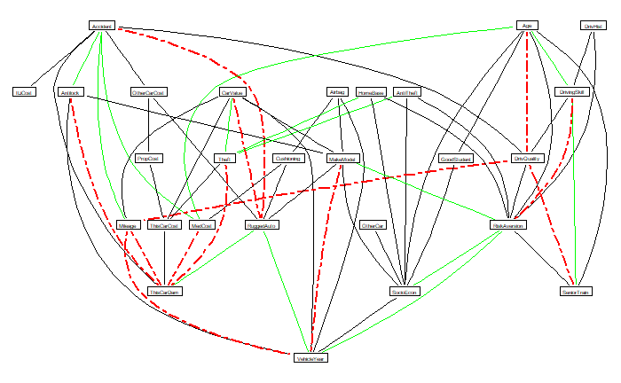

```r
graphviz.compare(bnlearn::skeleton(data),bnlearn::skeleton(myHc), layout = "dot", shape = "rectangle", main = NULL,
                 sub = NULL, diff = "from-first", diff.args = list(fp.col = "red", fp.lty = "twodash", fp.lwd = 2, fn.col = "green", fn.lty = "solid"))
```

la couleur rouge représente les faux positifs nous l’avons spécifié avec l’instruction fp.col = “red” et la couleur verte représente les faux négatifs. La méthode bnlearn::skeleton() permet de retirer les directions sur les graphes.

3. Constraint-based method (PC) (5 points)
1. Reconstruct the insurance network using the PC approach (pcalg::pc) using the disCItest conditional independence test. You will need to perform the following transformations:

```r
# Convert data to numeric
data_numeric <- data.matrix(insurance)

#Make the categories start from 0.
data_numeric <- data_numeric - 1

#Compute the number of levels for each variable
levels <- sapply(insurance, function(x) length(unique(x)))
levels


# Prepare the suffStat object
suffStat <- list(dm= data_numeric, n = nrow(data_numeric), levels = levels, adaptDF = FALSE)


pc.B <- pc(suffStat, indepTest = disCItest, alpha = 0.01, labels = colnames(insurance), verbose = TRUE)
```

2. Get the adjacency matrix (bnlearn::amat). (0.5 points)
3. Build a directed igraph network from the adjacency matrix and propose a (nice!) plot. (1 point)

Nous n’avons pas fini d’éxécuter ce bout de code du au temps pris par l’algorithme Pc qui a tourné plus de 30 minutes sans toute fois se terminer.

4. Get the number of true positive (TP), false positive (FP) and false negative (FN) using the bnlearn::compare function. Compute Precision, Recall and Fscore. (1 point)
5. Highlight the FP edges in your reconstructed network. (1 point)
4. Local search method (aracne) (4 points)
1. Reconstruct the insurance network using the PC approach (bnlearn::aracne). (0.5 points)
2. Get the adjacency matrix (bnlearn::amat). (0.5 points)
3. Build a directed igraph network from the adjacency matrix and propose a (nice!) plot. (1 point)

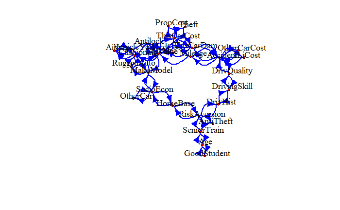

```r
graph_aracne <- graph_from_adjacency_matrix(myAcAdj,
                                                diag = FALSE,
                                                weight = TRUE,
                                                mode = "directed")

plot(graph_aracne, vertex.size=4, vertex.label.color = "black", vertex.label.cex=1.1, vertex.color = "red",vertex.label.dist=1,edge.arrow.size = 1
     ,edge.curved = 1, edge.color = "blue", edge.width = E(graph_aracne)$weight*2)
```

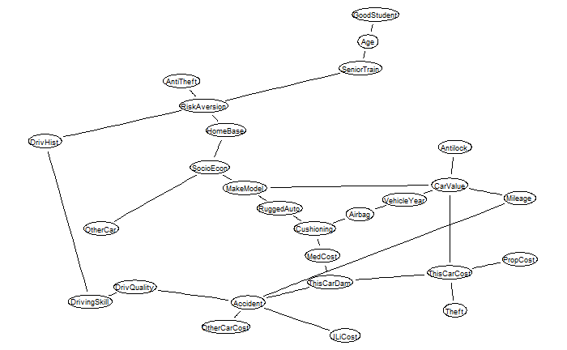

```r
graphviz.plot(myArac, shape = "ellipse", layout = "twopi")
```

4. Get the number of true positive (TP), false positive (FP) and false negative (FN) using the bnlearn::compare function. Compute Precision, Recall and Fscore. (1 point)

Nous procédons en deux étapes, premièrement nous allons nous intéresser aux résultats obtenus en tenant compte des directions et ensuite nous allons faire abstraction des directions et commenter les résultats.

1. Avec direction

```r
ac_comp <- bnlearn::compare(data,myArac)
ac_comp
```

```
$tp
[1] 0

$fp
[1] 30

$fn
[1] 52
```

```r
precision <- ac_comp$tp/(ac_comp$tp+ac_comp$fp)
recall <- ac_comp$tp/(ac_comp$tp+ac_comp$fn)
fscore <- 2*precision*recall/(precision+recall)
print(precision)
```

```
[1] 0
```

```r
print(recall)
```

```
[1] 0
```

```r
print(fscore)
```

```
[1] NaN
```

Nous obtenons que des 0 parce que aracne n’a pas d’orientation or nos données sont orientées du coup, pour avoir une bonne précision nous devons enlever l’orientation sur nos données originales comme suit:

```r
ac_comp <- bnlearn::compare(bnlearn::skeleton(data),myArac)
ac_comp
```

```
$tp
[1] 28

$fp
[1] 2

$fn
[1] 24
```

```r
precision <- ac_comp$tp/(ac_comp$tp+ac_comp$fp)
recall <- ac_comp$tp/(ac_comp$tp+ac_comp$fn)
fscore <- 2*precision*recall/(precision+recall)
print(precision)
```

```
[1] 0.9333333
```

```r
print(recall)
```

```
[1] 0.5384615
```

```r
print(fscore)
```

```
[1] 0.6829268
```

5. Highlight the FP edges in your reconstructed network. (1 point)

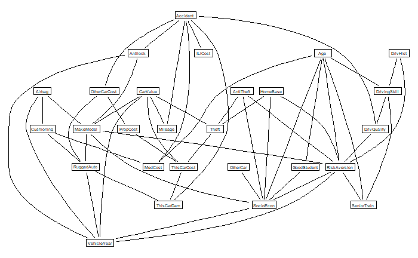

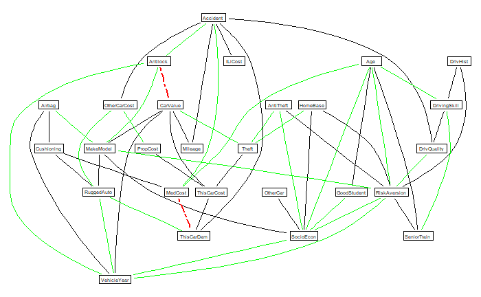

```r
graphviz.compare(bnlearn::skeleton(data),myArac, layout = "dot", shape = "rectangle", main = NULL, sub = NULL, diff = "from-first", diff.args = list(fp.col = "red", fp.lty = "twodash", fp.lwd = 2, fn.col = "green", fn.lty = "solid"))
```

Comme on peut le voir sur le graphe il y a uniquement 2 faux positifs.

Problématique II (5 points)

From the package MIIC, load the cosmicCancer data using the function data(). Explore the dataset content, variables and dimensions. (NB: The ’Ploidy’ variable may be interpreted as ’integer’. If necessary, convert this column into factor type.)

```r
# Load the cosmicCancer data
data("cosmicCancer")

# Explore the dataset content
head(cosmicCancer)
```

|  | bbc3 | egln1 | tgfb3 | esm1 | igfbp5 | fgf18 | scube2 | wisp1 | flt1 | hrasls | stk32b | rassf7 | dck | melk | ext1 | gnaz | ebf4 | mtdh | pitrm1 | qscn6l1 | ccne2 | ect2 | cenpa | lin9 | kntc2 | mcm6 | nusap1 | orc6l | tspyl5 | … |
| --- | --- | --- | --- | --- | --- | --- | --- | --- | --- | --- | --- | --- | --- | --- | --- | --- | --- | --- | --- | --- | --- | --- | --- | --- | --- | --- | --- | --- | --- | --- |
| 1 | n | n | n | n | n | n | n | n | n | n | n | n | n | n | n | n | n | n | n | n | n | n | n | n | n | n | n | n | n | … |
| 2 | n | n | n | n | n | n | n | n | n | n | n | n | n | n | n | n | n | n | n | n | n | n | n | n | n | n | n | n | n | … |
| 3 | n | n | n | n | n | n | n | n | n | n | n | n | n | n | n | n | n | n | n | n | n | n | n | n | n | n | n | n | n | … |
| 4 | n | n | n | n | n | n | n | n | n | n | n | n | n | n | n | n | n | n | n | n | n | n | n | n | n | n | n | n | n | … |
| 5 | n | n | n | n | n | n | n | n | n | n | n | n | n | n | n | n | n | n | n | n | n | n | n | n | n | n | n | n | n | … |
| 6 | n | n | n | n | n | n | n | n | n | n | n | n | n | n | n | n | n | n | n | n | n | n | n | n | n | n | n | n | n | … |

```r
# Explore the variables
names(cosmicCancer)
```

```
  [1] "bbc3"     "egln1"    "tgfb3"    "esm1"     "igfbp5"   "fgf18"    "scube2"
  [8] "wisp1"    "flt1"     "hrasls"   "stk32b"   "rassf7"   "dck"      "melk"
 [15] "ext1"     "gnaz"     "ebf4"     "mtdh"     "pitrm1"   "qscn6l1"  "ccne2"
 [22] "ect2"     "cenpa"    "lin9"     "kntc2"    "mcm6"     "nusap1"   "orc6l"
 [29] "tspyl5"   "rundc1"   "prc1"     "rfc4"     "recql5"   "cdca7"    "dtl"
 [36] "col4a2"   "gpr180"   "mmp9"     "gpr126"   "rtn4rl1"  "diaph3"   "cdc42bpa"
 [43] "palm2"    "aldh4a1"  "aytl2"    "oxct1"    "peci"     "gmps"     "gstm3"
 [50] "slc2a3"   "foxm1"    "erbb2"    "esr1"     "tp53"     "rb1"      "myc"
 [57] "jun"      "cdkn2a"   "bcl2"     "tp73"     "lats2"    "mapk14"   "cdkn1a"
 [64] "chek1"    "aurkb"    "aurka"    "brca1"    "brca2"    "dusp5"    "mst1"
 [71] "ppp1r13l" "birc3"    "tgfa"     "ets1"     "ets2"     "hif1a"    "ldha"
 [78] "foxo1"    "ndrg1"    "ppp2r1a"  "ppp2r2a"  "ccne1"    "apobec3b" "pten"
 [85] "mdm2"     "usp7"     "ube3a"    "spdye7p"  "plk1"     "bax"      "met"
 [92] "BBC3"     "EGLN1"    "TGFB3"    "ESM1"     "IGFBP5"   "FGF18"    "SCUBE2"
 [99] "WISP1"    "FLT1"     "HRASLS"   "STK32B"   "RASSF7"   "DCK"      "MELK"
[106] "EXT1"     "GNAZ"     "MTDH"     "PITRM1"   "CCNE2"    "ECT2"     "CENPA"
[113] "LIN9"     "MCM6"     "NUSAP1"   "TSPYL5"   "RUNDC1"   "PRC1"     "RFC4"
[120] "RECQL5"   "CDCA7"    "DTL"      "COL4A2"   "GPR180"   "MMP9"     "GPR126"
[127] "RTN4RL1"  "DIAPH3"   "CDC42BPA" "PALM2"    "ALDH4A1"  "OXCT1"    "GMPS"
[134] "GSTM3"    "SLC2A3"   "ERBB2"    "ESR1"     "TP53"     "RB1"      "MYC"
[141] "JUN"      "CDKN2A"   "BCL2"     "FOXM1"    "BRCA1"    "TP73"     "LATS2"
[148] "MAPK14"   "CDKN1A"   "CHEK1"    "BRCA2"    "AURKB"    "AURKA"    "APOBEC3B"
[155] "DUSP5"    "MST1"     "PPP1R13L" "BIRC3"    "TGFA"     "ETS1"     "ETS2"
[162] "HIF1A"    "LDHA"     "FOXO1"    "NDRG1"    "PPP2R1A"  "PPP2R2A"  "CCNE1"
[169] "PTEN"     "MDM2"     "USP7"     "UBE3A"    "PLK1"     "BAX"      "MET"
[176] "Ploidy"
```

```r
# Explore the dimensions
dim(cosmicCancer)
```

```
[1] 807 176
```

```r
# Convert Ploidy variable to factor type if necessary
if(is.integer(cosmicCancer$Ploidy)){
  cosmicCancer$Ploidy <- as.factor(cosmicCancer$Ploidy)
}
```

2. Explain the arguments confidenceShuffle and confidenceThreshold. Get sev- eral networks with different values for these arguments.

L’argument n_shuffles représente le nombre de mélanges de l’ensemble de données d’origine afin d’évaluer le rapport de confiance spécifique aux arêtes de tous les arêtes inférés.

L’argument conf_threshold représente le seuil utilisé pour filtrer les arêtes les moins probables suivant l’étape squelette.

3. Convert the MIIC network to an igraph object and plot the result. Some variables can have 0 degree.

```r
miic <- miic(cosmicCancer, n_shuffles = 50, conf_threshold = 0.01)
```

```
Search all pairs for unconditional independence relations...
Search for candidate separating nodes...
```

[output not shown]

[output cut: 46 more lines]

[output not shown]

```
Search for conditional independence relations...
```

[output not shown]

[output cut: 46 more lines]

[output not shown]

```
Compute confidence cut with permutations...362 edges cut.
Search for edge directions...
Number of edges: 138
```

```r
graph_miic <- graph_from_adjacency_matrix(miic$adj_matrix)
graph_miic <- delete.vertices(graph_miic, which(igraph::degree(graph_miic) == 0))
```

```r
# Assign different colors to the nodes based on their type
V(graph_miic)$color[grep("[a-z]", V(graph_miic)$name)] <- "yellow"
V(graph_miic)$color[grep("[A-Z]", V(graph_miic)$name)] <- "green"
V(graph_miic)$color[grep("Ploidy", V(graph_miic)$name)] <- "purple"
```

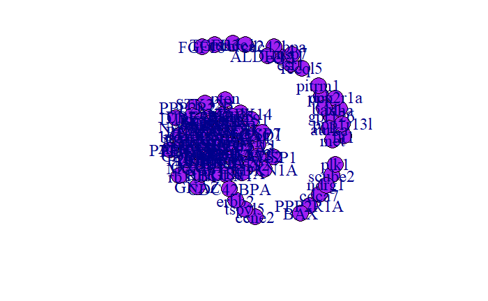

```r
plot(graph_miic,
  vertex.size = 19,
  vertex.label.cex = 1.5,
  vertex.color = "purple",
  edge.color = "gray",
  edge.arrow.size = 0.5,
  layout = layout_with_kk)
```

```r
nodes_to_keep <- V(g)$name[igraph::degree(g) > 0]
nodes_to_keep
```

```
  [1] "scube2"   "flt1"     "dck"      "pitrm1"   "ccne2"    "ect2"     "nusap1"   "tspyl5"   "rundc1"   "recql5"   "cdca7"
 [12] "gpr126"   "cdc42bpa" "erbb2"    "esr1"     "tp53"     "rb1"      "aurka"    "brca1"    "brca2"    "ppp1r13l" "ldha"
 [23] "ndrg1"    "ppp2r1a"  "pten"     "usp7"     "plk1"     "bax"      "met"      "EGLN1"    "TGFB3"    "ESM1"     "FGF18"
 [34] "SCUBE2"   "WISP1"    "FLT1"     "HRASLS"   "STK32B"   "DCK"      "MELK"     "EXT1"     "GNAZ"     "MTDH"     "PITRM1"
 [45] "CCNE2"    "ECT2"     "CENPA"    "LIN9"     "MCM6"     "NUSAP1"   "TSPYL5"   "RUNDC1"   "PRC1"     "RFC4"     "CDCA7"
 [56] "DTL"      "COL4A2"   "GPR180"   "GPR126"   "DIAPH3"   "CDC42BPA" "PALM2"    "ALDH4A1"  "OXCT1"    "GMPS"     "SLC2A3"
 [67] "ESR1"     "TP53"     "RB1"      "MYC"      "CDKN2A"   "FOXM1"    "BRCA1"    "TP73"     "LATS2"    "MAPK14"   "CDKN1A"
 [78] "CHEK1"    "BRCA2"    "AURKB"    "AURKA"    "APOBEC3B" "BIRC3"    "TGFA"     "ETS1"     "ETS2"     "HIF1A"    "LDHA"
 [89] "FOXO1"    "NDRG1"    "PPP2R1A"  "PPP2R2A"  "CCNE1"    "PTEN"     "MDM2"     "USP7"     "UBE3A"    "PLK1"     "BAX"
[100] "Ploidy"
```

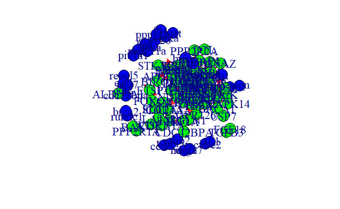

```r
#installer et charger qgraph
#install.packages("qgraph")
library(qgraph)
#mettre des couleurs différentes pour les gènes mutés, surexprimés/sous-exprimés et Ploidy
V(graph_miic)$color <- ifelse(grepl("[a-z]", V(graph_miic)$name), "blue",
                            ifelse(grepl("[A-Z]", V(graph_miic)$name), "green", "red"))
#utiliser la fonction qgraph.layout.fruchtermanreingold pour la disposition du graphe
#qgraph.layout.fruchtermanreingold(g_subset)
#dessiner le graphe
plot(graph_miic,
  vertex.size = 19,
  vertex.label.cex = 1.5,
  vertex.color = V(graph_miic)$color,
  edge.color = "red",
  edge.arrow.size = 1)
```